# JSC370 MIDTERM REPORT

Siyi Zhu | [GitHub](https://github.com/Sophiaaa12/JSC370---Project)

2025-03-17

# Introduction:

This dataset is about “Traveller volumes by port of entry and month” from Government of Canada. I have called API to load the dataset from 2018-01-01 to 2019-05-24 due to the limit. It includes details such as **date, port of entry, region, mode of transportation, and the volume of crossings**. Understanding border traffic is essential for transportation planning, security, and economic forecasting.

Therefore, my research question will be: **How do seasonal and regional factors affect border crossings in Canada from January 2018 to May 2019?**

Within this question, there are three three hypothesis I can make:  
1. **Border crossings follow a seasonal pattern**, peaking during summer months due to increased tourism and declining in winter.  
2. **Land border crossings are the most frequent** due to frequent travel between Canada and the U.S.  
3. **Certain regions experience significantly higher border crossings** compared to others, reflecting population density and economic activity.

# Methods:

## How and where the data were acquired?

The data is an open data posted on the website of Government of Canada. It enabled API and I acquired it by calling API in RStudio.

## How you cleaned and wrangled the data?

Since the dataset is large, we should ensure we can deal with data better and efficient in the following steps:  
- **Converting date columns** to a standardized format (Rename and Change the variable type to the standardized one).  
- **Handling missing values**, ensuring no significant data loss.  
- **Remove unusal values or non-make sense values**, ensuring the data is correct.  
- **Aggregating data** to analyze trends over time, by region, by transportation mode and etc..

## What tools you used for data exploration?

I used the following R packages for data manipulation, visualization, and time series analysis:  
- tidyverse, dplyr, and ggplot2 for data wrangling and visualization.  
- forecast, timetk for time series analysis.  
- kableExtra to generate summary tables for analysis.

This approach ensures a structured and comprehensive analysis of border crossing trends in Canada.

# Preliminary Results:

## Summary statistics by transportation mode

From the summary table, we observe that land border crossings have the highest total volume, while rail crossings are the least frequent. Although air travel crossings are fewer in total than land, their maximum daily volume exceeds land crossings, indicating occasional travel spikes. Marine crossings, while lower in total volume, show notable peak activity, likely reflecting seasonal ferry travel. These variations suggest that seasonality and transportation infrastructure play a crucial role in border traffic trends.

Summary of Border Crossings by Transportation Mode

| Mode | Total_Volume | Average_Volume | Max_Volume |
| --- | --- | --- | --- |
| Air | 50413350 | 3094.74217 | 34026 |
| Land | 77118323 | 1136.43270 | 27369 |
| Marine | 3382240 | 301.93180 | 17837 |
| Rail | 301634 | 64.89544 | 1424 |

## Data Visualization

### Trend of Border Crossings Over Time

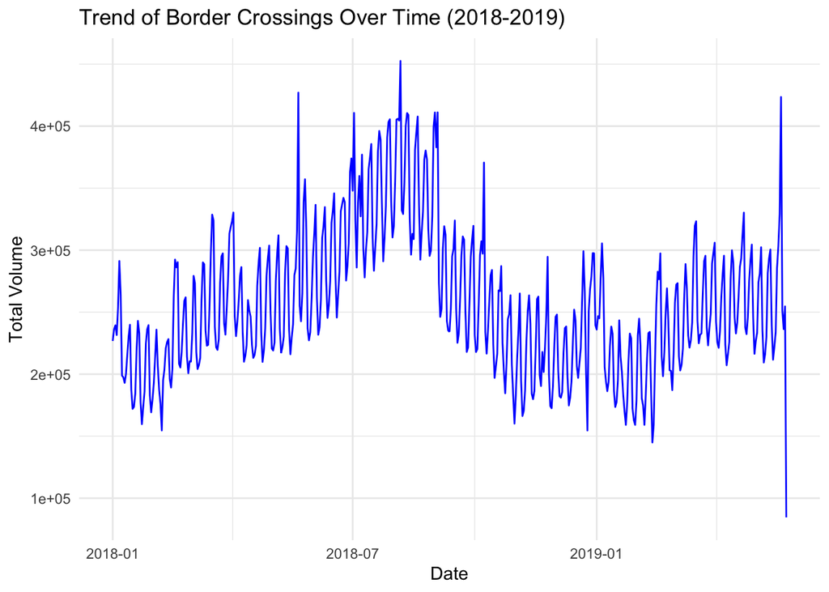

### Trend of Border Crossings by Region

The bar chart illustrates total border crossings by region, showing Southern Ontario and the Pacific Region as the two most active regions and each has over 30 million crossings. The Greater Toronto Area follows. In contrast, the Quebec, Prairie, Northern Ontario, and Atlantic regions experience progressively fewer crossings, with the Atlantic Region having the lowest total volume. The dominance of Southern Ontario and the Pacific Region suggests that major urban centers and key border points significantly influence travel volumes.

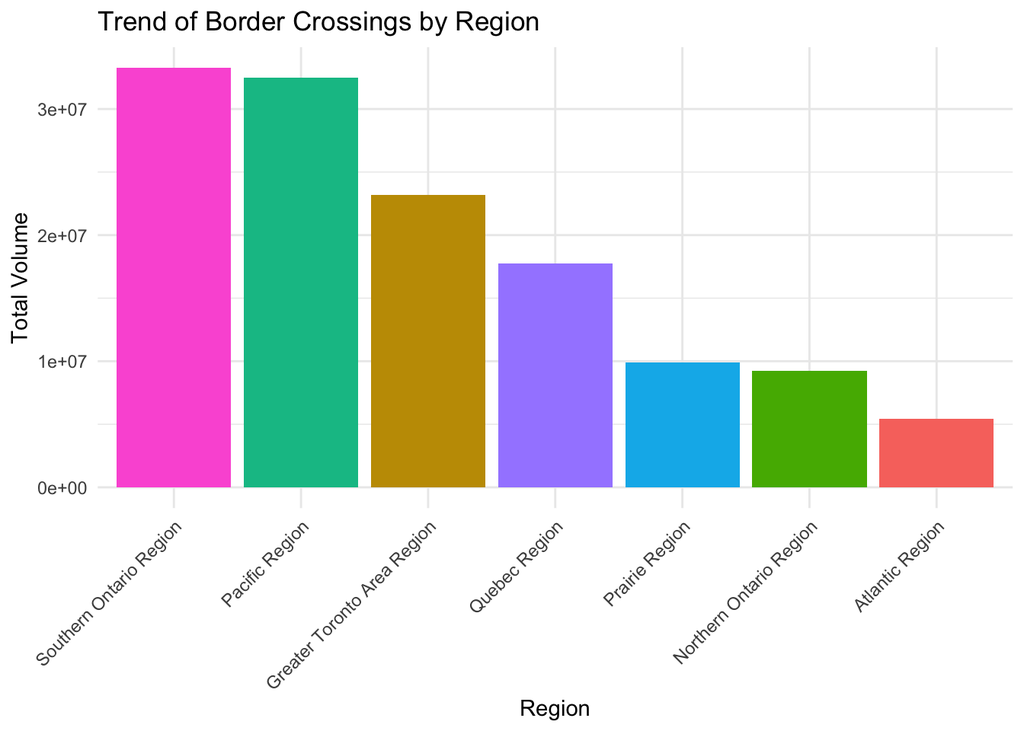

### Transportation Mode Trends

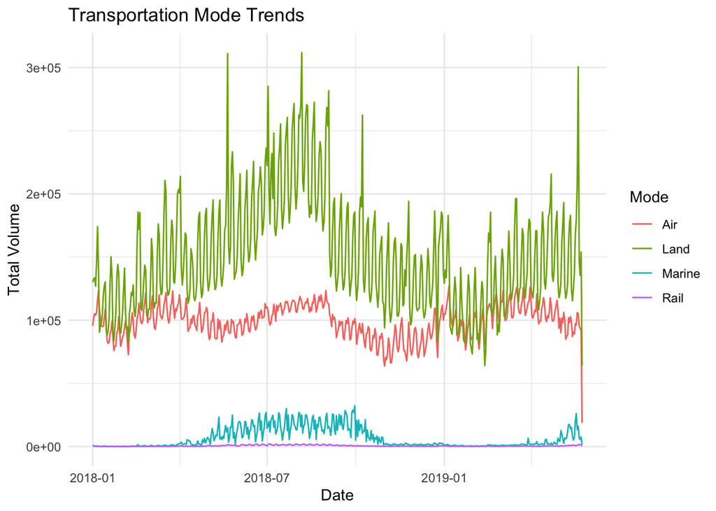

# Summary:

## Plan of next steps:

To deepen my analysis, I will conduct monthly and seasonal assessments to quantify the seasonal effects on border traffic. To validate key observations, I plan to apply statistical hypothesis testing:  
- A t-test will compare weekday and weekend traffic volumes to assess whether weekends experience significantly higher crossings.  
- An ANOVA test will be used to determine whether regional and transportation mode differences in border crossing volumes are statistically significant.  
- Time series decomposition will be applied to separate trend, seasonal, and residual components, providing a clearer understanding of cyclical and long-term patterns.

Finally, I will synthesize these results into a comprehensive final report, integrating analysis and conclusions to present a well-supported investigation into the impact of seasonal and regional factors on border crossings.